# Regression Analytics

Dev

2023-11-04

## R Markdown

**Q-1:Run the following code in R-studio to create two variables X and Y.** **set.seed(2017)** **X=runif(100)*10 Y=X*4+3.45** **Y=rnorm(100)*0.29*Y+Y**

```r
set.seed(2017)
X=runif(100)*10
Y=X*4+3.45
Y=rnorm(100)*0.29*Y+Y
```

**a) Plot Y against X. Include a screenshot of the plot in your submission. Using the file menu you can save the graph as a picture on your computer. Based on the plot do you think we can fit a linear model to explain Y based on X? (8% of total points)**

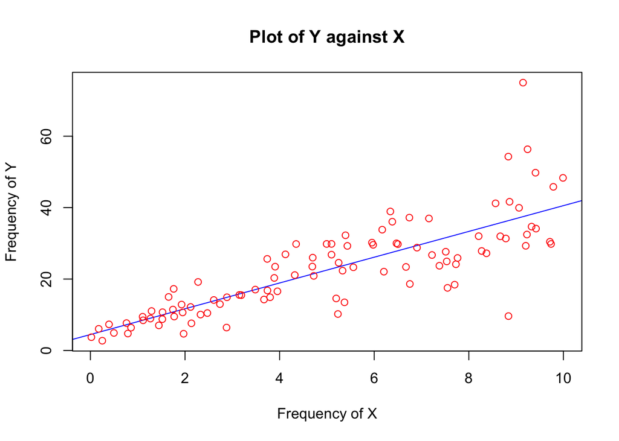

```r
plot(X,Y,xlab="Frequency of X",ylab = "Frequency of Y", main = "Plot of Y against X",col="red",abline(lm(Y~X),col="blue"))
```

We can clearly see that the above graph shows a positive linear relationship between X and Y.Most of the data points follow the linear model line. However, there are some outliers but majority of the points follow a positive linear regression. Hence, we can conclude that we can in fact use a linear model to explain relationship of X and Y.

**b) Construct a simple linear model of Y based on X. Write the equation that explains Y based on X. What is the accuracy of this model? (8% of total points)**

```r
model=lm(Y~X)
```

We can now get coefficient and intercept of relation between X and Y as:

```r
round(model$coefficients,2)
```

```
(Intercept)           X
       4.47        3.61
```

Hence, we can write equation of Y and X as follows:
$$Y=b_nX+b_o$$
$$=>Y=3.61X+4.47$$

Accuracy of above model is :

```r
summary(model)
```

```
Call:
lm(formula = Y ~ X)

Residuals:
    Min      1Q  Median      3Q     Max
-26.755  -3.846  -0.387   4.318  37.503

Coefficients:
            Estimate Std. Error t value Pr(>|t|)
(Intercept)   4.4655     1.5537   2.874  0.00497 **
X             3.6108     0.2666  13.542  < 2e-16 ***
---
Signif. codes:  0 '***' 0.001 '**' 0.01 '*' 0.05 '.' 0.1 ' ' 1

Residual standard error: 7.756 on 98 degrees of freedom
Multiple R-squared:  0.6517,    Adjusted R-squared:  0.6482
F-statistic: 183.4 on 1 and 98 DF,  p-value: < 2.2e-16
```

The accuracy of model is the value of multiple R-squared. Hence, our model is 65% accurate. A smaller p value here shows us that the relationship is significant between both variables. This is also evident from smaller difference between multiple- squared ad adjusted r-squared.

**c) How the Coefficient of Determination, R 2, of the model above is related to the correlation coefficient of X and Y? (8% of total points)**

In a linear regression model square of correlation coefficient and Multiple R-squared are equal.

Value of Correlation coefficient can be calculated as:

```r
cor(X,Y)^2
```

```
[1] 0.6517187
```

**Q-2:We will use the ‘mtcars’ dataset for this question. The dataset is already included in your R distribution. The dataset shows some of the characteristics of different cars.**

```r
#Printing head of dataset to have a glance at it:
head(mtcars)
```

```
                   mpg cyl disp  hp drat    wt  qsec vs am gear carb
Mazda RX4         21.0   6  160 110 3.90 2.620 16.46  0  1    4    4
Mazda RX4 Wag     21.0   6  160 110 3.90 2.875 17.02  0  1    4    4
Datsun 710        22.8   4  108  93 3.85 2.320 18.61  1  1    4    1
Hornet 4 Drive    21.4   6  258 110 3.08 3.215 19.44  1  0    3    1
Hornet Sportabout 18.7   8  360 175 3.15 3.440 17.02  0  0    3    2
Valiant           18.1   6  225 105 2.76 3.460 20.22  1  0    3    1
```

**a) James wants to buy a car. He and his friend, Chris, have different opinions about the Horse Power (hp) of cars. James think the weight of a car (wt) can be used to estimate the Horse Power of the car while Chris thinks the fuel consumption expressed in Mile Per Gallon (mpg),is a better estimator of the (hp). Who do you think is right? Construct simple linear models using mtcars data to answer the question. (17% of total points).**

Making James model-

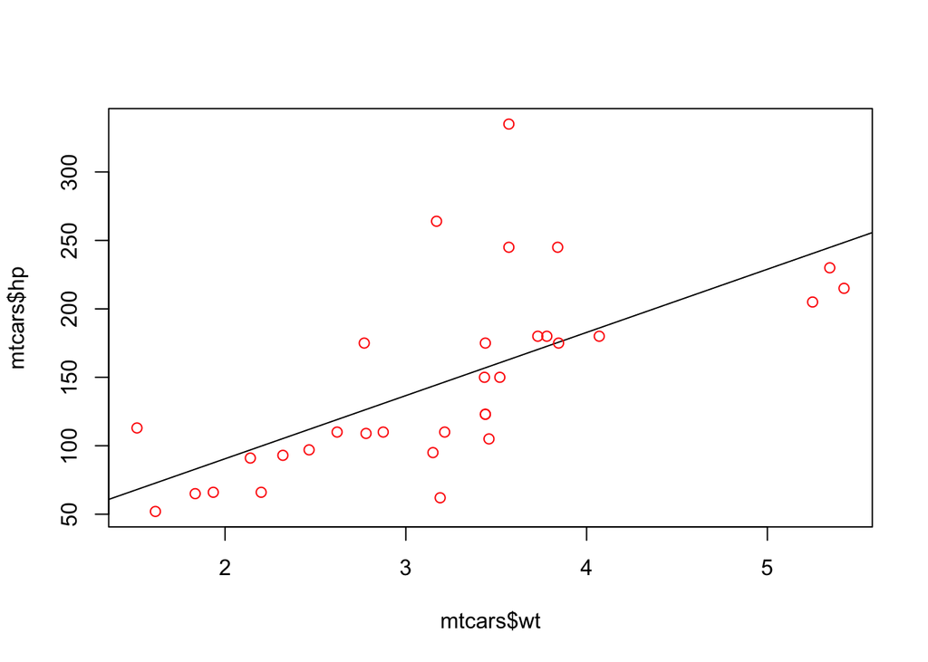

```r
james=lm(mtcars$hp~mtcars$wt,data = mtcars)
plot(mtcars$wt,mtcars$hp,col="red",abline(lm(mtcars$hp~mtcars$wt)))
```

```r
summary(james)
```

```
Call:
lm(formula = mtcars$hp ~ mtcars$wt, data = mtcars)

Residuals:
    Min      1Q  Median      3Q     Max
-83.430 -33.596 -13.587   7.913 172.030

Coefficients:
            Estimate Std. Error t value Pr(>|t|)
(Intercept)   -1.821     32.325  -0.056    0.955
mtcars$wt     46.160      9.625   4.796 4.15e-05 ***
---
Signif. codes:  0 '***' 0.001 '**' 0.01 '*' 0.05 '.' 0.1 ' ' 1

Residual standard error: 52.44 on 30 degrees of freedom
Multiple R-squared:  0.4339,    Adjusted R-squared:  0.4151
F-statistic:    23 on 1 and 30 DF,  p-value: 4.146e-05
```

Making Chris model-

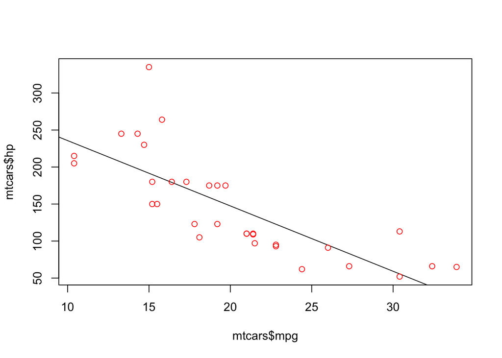

```r
chris=lm(mtcars$hp~mtcars$mpg,data = mtcars)
plot(mtcars$mpg,mtcars$hp,col="red",abline(lm(mtcars$hp~mtcars$mpg)))
```

```r
summary(chris)
```

```
Call:
lm(formula = mtcars$hp ~ mtcars$mpg, data = mtcars)

Residuals:
   Min     1Q Median     3Q    Max
-59.26 -28.93 -13.45  25.65 143.36

Coefficients:
            Estimate Std. Error t value Pr(>|t|)
(Intercept)   324.08      27.43  11.813 8.25e-13 ***
mtcars$mpg     -8.83       1.31  -6.742 1.79e-07 ***
---
Signif. codes:  0 '***' 0.001 '**' 0.01 '*' 0.05 '.' 0.1 ' ' 1

Residual standard error: 43.95 on 30 degrees of freedom
Multiple R-squared:  0.6024,    Adjusted R-squared:  0.5892
F-statistic: 45.46 on 1 and 30 DF,  p-value: 1.788e-07
```

Value of R-squared is larger for Chris’s opinion which means he has accuracy,i.e, **Chris’s model is more accuracte and correct.**

**b) Build a model that uses the number of cylinders (cyl) and the mile per gallon (mpg) values of a car to predict the car Horse Power (hp). Using this model, what is the estimated Horse Power of a car with 4 cylinders and mpg of 22? (17% of total points)**

```r
model.2=lm(hp~cyl+mpg,data=mtcars)
df=data.frame(cyl=4,mpg=22)
prediction=predict(model.2,newdata = df)
prediction
```

```
       1
88.93618
```

Hence, according to created model value of horse power would be **88.93618**.

**Q-3:The dataset contains information about houses in different parts of Boston. Details of the dataset is explained here. Note the dataset is old, hence low house prices!**

Using required dataset:

```r
library(mlbench)
data(BostonHousing)
```

**a) Build a model to estimate the median value of owner-occupied homes (medv)based on the following variables: crime crate (crim), proportion of residential land zoned for lots over 25,000 sq.ft (zn), the local pupil-teacher ratio (ptratio) and weather the whether the tract bounds Chas River(chas). Is this an accurate model? (Hint check R 2 ) (8% of total points)** Making the required linear model:

```r
model.3=lm(medv~crim+zn+ptratio+chas,BostonHousing)
summary(model.3)
```

```
Call:
lm(formula = medv ~ crim + zn + ptratio + chas, data = BostonHousing)

Residuals:
    Min      1Q  Median      3Q     Max
-18.282  -4.505  -0.986   2.650  32.656

Coefficients:
            Estimate Std. Error t value Pr(>|t|)
(Intercept) 49.91868    3.23497  15.431  < 2e-16 ***
crim        -0.26018    0.04015  -6.480 2.20e-10 ***
zn           0.07073    0.01548   4.570 6.14e-06 ***
ptratio     -1.49367    0.17144  -8.712  < 2e-16 ***
chas1        4.58393    1.31108   3.496 0.000514 ***
---
Signif. codes:  0 '***' 0.001 '**' 0.01 '*' 0.05 '.' 0.1 ' ' 1

Residual standard error: 7.388 on 501 degrees of freedom
Multiple R-squared:  0.3599,    Adjusted R-squared:  0.3547
F-statistic: 70.41 on 4 and 501 DF,  p-value: < 2.2e-16
```

All variables here are significant but lower value of multiple-R squared tells us that model has a very low accuracy of 35.99%. Hence, it is not an accurate model.

**b) Use the estimated coefficient to answer these questions?**

Displaying coefficients for reference:

```r
model.3$coefficients
```

```
(Intercept)        crim          zn     ptratio       chas1
49.91868439 -0.26017612  0.07072809 -1.49367255  4.58392591
```

**I. Imagine two houses that are identical in all aspects but one bounds the Chas River and the other does not. Which one is more expensive and by how much? (8% of total points)**

Value of coefficient for chas1 is positive. This means that the house that bounds the chas river will be more expensive by 4.58392591.

**II. Imagine two houses that are identical in all aspects but in the neighborhood of one of them the pupil-teacher ratio is 15 and in the other one is 18. Which one is more expensive and by how much? *(Golden Question: 4% extra)**

Value of coefficient for pupil-teacher ratio is negative. This means that the house with a higher pupil-teacher ratio (18) will have a lesser price than the house with a lowere pupil-teacher ratio(15) by :

```r
18*1.49367255-15*1.49367255
```

```
[1] 4.481018
```

**c) Which of the variables are statistically important (i.e. related to the house price)? Hint: use the p-values of the coefficients to answer. (8% of total points)**

All of the variables are statistically important since all of them have a low p-value.

**d) Use the anova analysis and determine the order of importance of these four variables. (18%of total points)**

```r
anova(model.3)
```

```
Analysis of Variance Table

Response: medv
           Df  Sum Sq Mean Sq F value    Pr(>F)
crim        1  6440.8  6440.8 118.007 < 2.2e-16 ***
zn          1  3554.3  3554.3  65.122 5.253e-15 ***
ptratio     1  4709.5  4709.5  86.287 < 2.2e-16 ***
chas        1   667.2   667.2  12.224 0.0005137 ***
Residuals 501 27344.5    54.6
---
Signif. codes:  0 '***' 0.001 '**' 0.01 '*' 0.05 '.' 0.1 ' ' 1
```

Order of importance can be found on the basis of values of Sum sq. Hence, the order of important can be deduced out of anova analysis as:

**crim** **ptratio** **zn** **chas**